# Regression exercise

Fábio Rocha Campos

8 de agosto de 2017

## Executive Summary

I work to a Motor Trend, a magazine about the automobile industry. In this study I show the relationship of Miles per Gallon (MPG) to 10 aspects of automobile design. The main objective is to anwser the two questions below:

“Is an automatic or manual transmission better for MPG”

“Quantify the MPG difference between automatic and manual transmissions”

The results of this study verify that the manual transmission should be better than automatic transmission for mpg if we consider only these element(transmission). However when we look for other variables like Weight it is possible to observe that a car with manual transmission will have 0.0236 less miles per galleon than a similar car with automatic transmission.

## Data Processing

The variables present in the dataset are:

```
mpg - Miles/(US) gallon
cyl - Number of cylinders
disp - Displacement (cu.in.)
hp - Gross horsepower
drat - Rear axle ratio
wt - Weight (lb/1000)
qsec - 1/4 mile time
vs - V/S
am - Transmission (0 = automatic, 1 = manual)
gear - Number of forward gears
carb - Number of carburators
```

1. A briefly analysis of variables

First, is important to convert the “am” variable to a factor and put in a correct classification like “Automatic” and “Manual”. After we show some simples analysis to know about the variable ‘MPG’ and ‘AM’.

```r
library(car)
mtcars$am = as.factor(mtcars$am)
levels(mtcars$am) = c("Automatic", "Manual")
summary(mtcars$mpg); summary(mtcars$am)
```

```
##    Min. 1st Qu.  Median    Mean 3rd Qu.    Max.
##   10.40   15.43   19.20   20.09   22.80   33.90
```

```
## Automatic    Manual
##        19        13
```

## Exploratory analysis

In a exploratory analysis, first, shows a scatterplot dividing the relation of variables considering the differents types of transmission.

2. A Scatterplot to check the relations of MPG variables and some variables separating by type of transmission

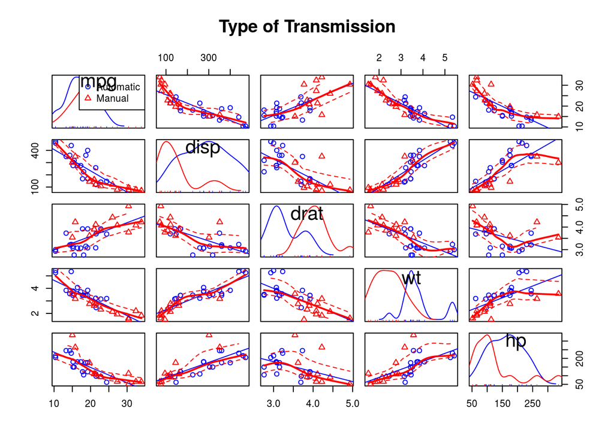

```r
scatterplotMatrix(~mpg+disp+drat+wt+hp|am, data=mtcars,
                   col = c("blue", "red"),
                   main="Type of Transmission")
```

The boxplot below show us that if we consider the cars that have manual transmission they appears little bit more economic and efficiently than cars with automatic transmission.

3. Boxplot to check what the type of transmission could be more efficiently to gas consumption.

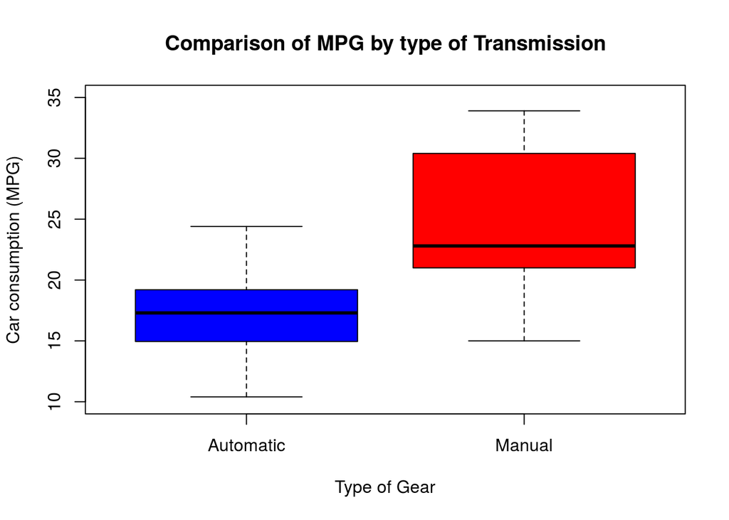

```r
autmanbox = boxplot(mpg ~ am, data=mtcars, main = "Comparison of MPG by type of Transmission",
              xlab = "Type of Gear",
              ylab = "Car consumption (MPG)",
              ylim = c(10, 35),
              col = c("blue", "red"))
```

To check more precising the relations of variable it is necessary to verify the correlations. In this case, indicate to us that weight has a important correlation to MPG variable.

4. A correlation analysis of MPG variable and others.

```r
cor(mtcars[, -c(9)])[1, ]
```

```
##        mpg        cyl       disp         hp       drat         wt
##  1.0000000 -0.8521620 -0.8475514 -0.7761684  0.6811719 -0.8676594
##       qsec         vs       gear       carb
##  0.4186840  0.6640389  0.4802848 -0.5509251
```

5. A decision to analyse the relation of Weight variable.

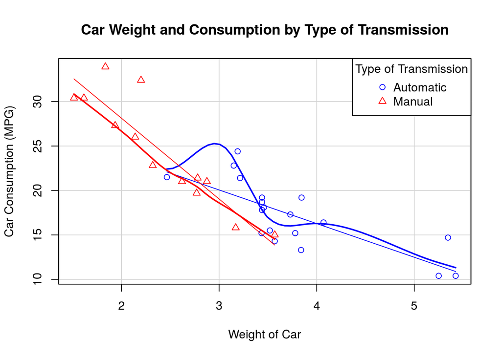

```r
wtplot = scatterplot(mpg ~ wt | am, data=mtcars,
                     xlab="Weight of Car", ylab="Car Consumption (MPG)",
                     main="Car Weight and Consumption by Type of Transmission",
                     col = c("blue", "red"),
                     legend.title = "Type of Transmission",
                     legend.coords = "topright")
```

## Linear models

6.1 Fit 1

```r
fit1 = lm(mpg ~ am, data=mtcars)
rmse1 = sqrt(sum(fit1$residuals ^ 2) / nrow(mtcars))
rsq1 = summary(fit1)$r.squared
```

6.2 Fit 2

```r
fit2 = lm(mpg ~ wt, data=mtcars)
rmse2 = sqrt(sum(fit2$residuals ^ 2) / nrow(mtcars))
rsq2 = summary(fit2)$r.squared
```

6.3 Fit 3

```r
fit3 = lm(mpg ~ am + wt, data=mtcars)
rmse3 = sqrt(sum(fit3$residuals ^ 2) / nrow(mtcars))
rsq3 = summary(fit3)$r.squared
```

7. Residual analysis

7.1 Residuals Plot

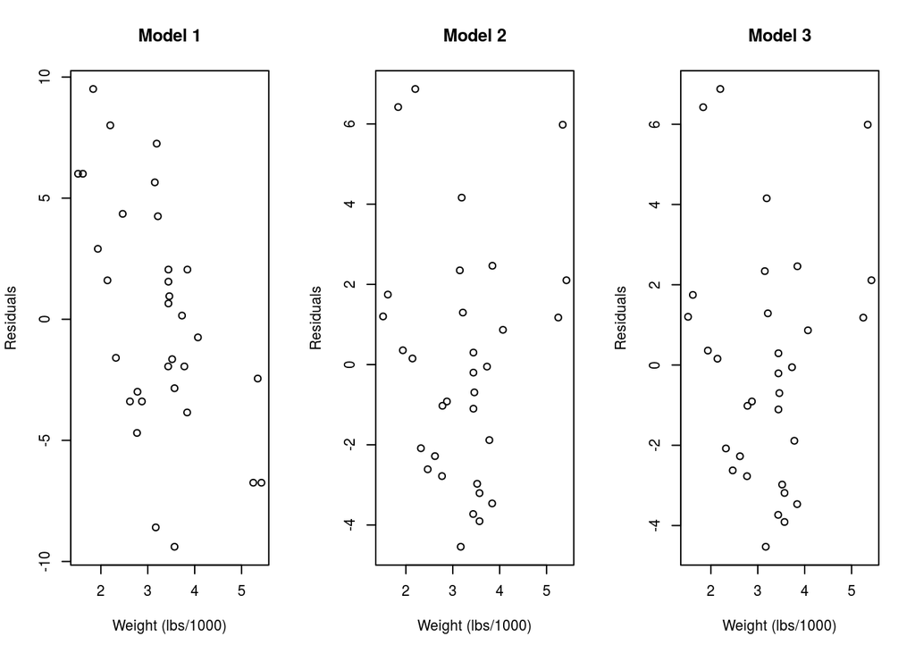

```r
par(mfcol = c(1, 3))
plot(mtcars$wt, resid(fit1), main = "Model 1", xlab = "Weight (lbs/1000)", ylab = "Residuals")
plot(mtcars$wt, resid(fit2), main = "Model 2", xlab = "Weight (lbs/1000)", ylab = "Residuals")
plot(mtcars$wt, resid(fit3), main = "Model 3", xlab = "Weight (lbs/1000)", ylab = "Residuals")
```

The residuals for model 1 exhibit a linear pattern. Model 1 has larger residuals than the other two models.The residuals of models 2 and 3 are almost identical.

7.2 table of comparison - Root Mean Squared Error

```
## [1] "Model 1 =  4.74636900427014"
```

```
## [1] "Model 2 =  2.94916268595503"
```

```
## [1] "Model 3 =  2.94915081645569"
```

7.3 Table of compartison - R2

```
## [1] "Model 1 =  0.359798943425465"
```

```
## [1] "Model 2 =  0.752832793658264"
```

```
## [1] "Model 3 =  0.752834783202689"
```

Model 1 does not predict MPG very well, models 2 and 3 have very similar performance characteristics. The R2 values reveals the fact that adding the transmission type to model 2 does not add any predictive power.

7.4 Coefficients

Coefficient Model 2:

```r
coef2 = summary(fit2)$coef
coef2
```

```
##              Estimate Std. Error   t value     Pr(>|t|)
## (Intercept) 37.285126   1.877627 19.857575 8.241799e-19
## wt          -5.344472   0.559101 -9.559044 1.293959e-10
```

Coefficient Model 3:

```r
coef3 = summary(fit3)$coef
coef3
```

```
##                Estimate Std. Error     t value     Pr(>|t|)
## (Intercept) 37.32155131  3.0546385 12.21799285 5.843477e-13
## amManual    -0.02361522  1.5456453 -0.01527855 9.879146e-01
## wt          -5.35281145  0.7882438 -6.79080719 1.867415e-07
```

```r
transmission_ci <- coef3[2, 1] + c(-1, 1) * qt(.975, df = fit3$df) * coef3[2, 2]
transmission_ci
```

```
## [1] -3.184815  3.137584
```

The coefficient for the transmission variable has an estimated value of -0.0236, meaning that a car with manual transmission will have 0.0236 less miles per galleon than a similar car with automatic transmission. The 95% confidence interval for this coefficient is rather large compared to its estimated value, namely (-3.1848, 3.1376). To provide a basis for comparison, an increase in weight of 1000 lbs would lower the MPG by an average of 5.3528.

## Conclusion

The large width of the confidence interval means that the estimated difference between the cars with manual and automatic transmission should not be taken at face value and a more detailed analysis is necessary.